# How Sunk Investment Changes Bargaining Power

Stephen Weymouth

Dean’s Professor

2026-10-19

# In 1910 Sam Zemurray borrowed $2,000 to buy 5,000 acres in Honduras. In 1929 he sold out for more than $30 million.

## Your IB Voice

Explain the sale

In 1911 Zemurray paid for a war in Honduras to protect his concessions. In 1929 he sold his company to his largest rival. What had changed about his bargaining position?

**10 minutes** · Individual · Notes permitted

## Competing explanations

What had changed by 1929?

Zemurray had far more to lose in 1929 than in 1911.

The State Department wanted the two companies merged.

The president of Honduras had sided with United Fruit.

The stock market crash made a large company look safer.

United Fruit’s stock would make him one of the richest men in the country.

Which of these would have mattered to a firm that owned nothing in Honduras?

# Why buy jungle with borrowed money?

## Zemurray bet everything on land in Honduras

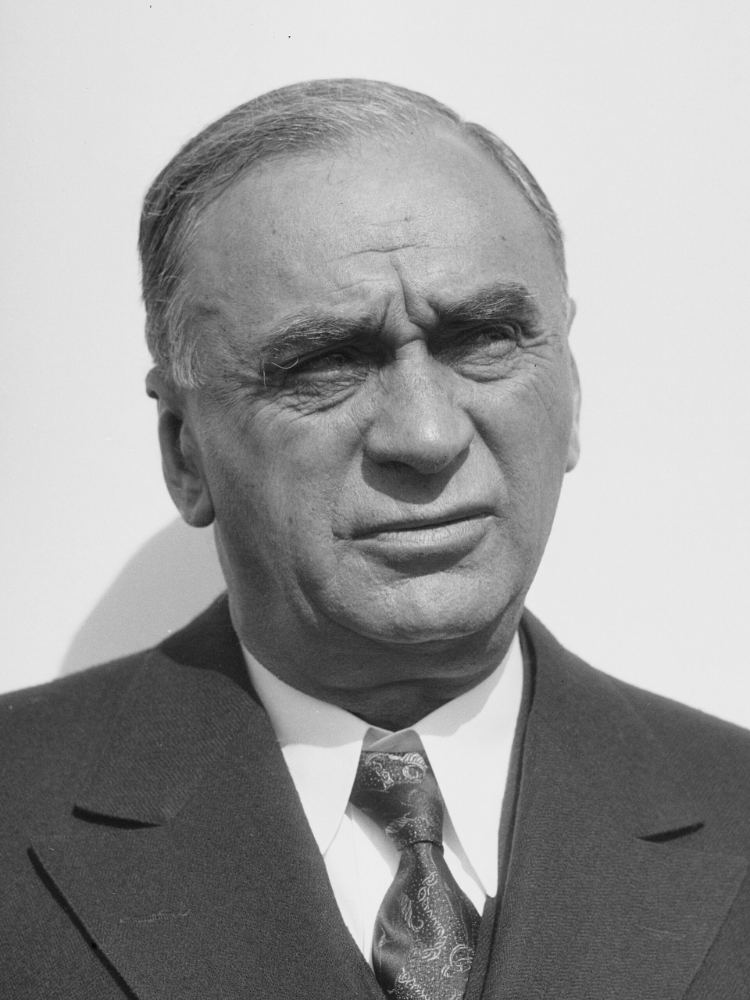

Los Angeles Times, [*Sam Zemurray, 1934*](https://commons.wikimedia.org/wiki/File:Sam_Zemurray,_1934.jpg) · UCLA Library via Wikimedia Commons, CC BY 4.0.

The peasants who sold him the Cuyamel delta saw swamp, but Zemurray saw the best banana soil in the world.

When banks stopped lending, he borrowed at close to 50 percent and bought out his cautious partner.

Before he invested, Honduras needed Zemurray’s money more than he needed Honduras.

## Concessions made the business possible

Dávila’s government exempted Cuyamel from duties on rails, engines, and machetes, and from property, labor, and export taxes.

A penny more per bunch would have priced his bananas above United Fruit’s.

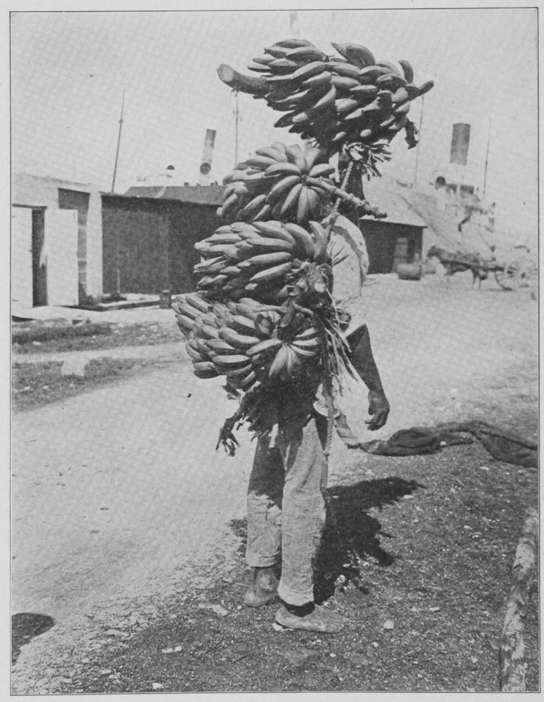

Willis J. Abbot, [*One way of carrying bananas*](https://commons.wikimedia.org/wiki/File:Trabajador_United_Fruit_Company,_1913.tif), 1913 · New York Public Library via Wikimedia Commons, public domain.

Once built, the rails and wharves were worth something only in Honduras, and only on those terms.

# What happens when the government changes?

## Washington’s debt plan would end his concessions

Honduras owed $100 million on 60 miles of railroad, and Secretary of State Philander Knox feared British warships would come to collect.

His plan seated J. P. Morgan’s officers in the Honduran customs house, ending tax breaks like Zemurray’s.

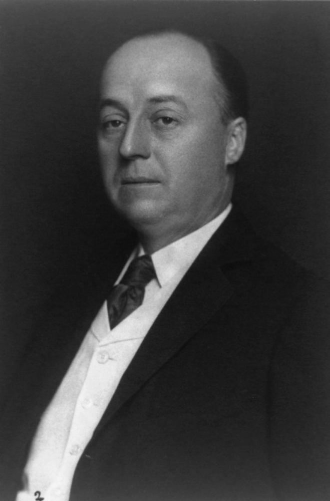

C. A. Jarrett, [*Philander Knox*](https://commons.wikimedia.org/wiki/File:Philander_Knox,_bw_photo_portrait,_1904.jpg), 1904 · Library of Congress via Wikimedia Commons, public domain.

The threat to Zemurray’s investment came from Washington and Wall Street.

# Zemurray did not renegotiate. He paid for a war to put Manuel Bonilla back in power.

## Zemurray changed the government, not the deal

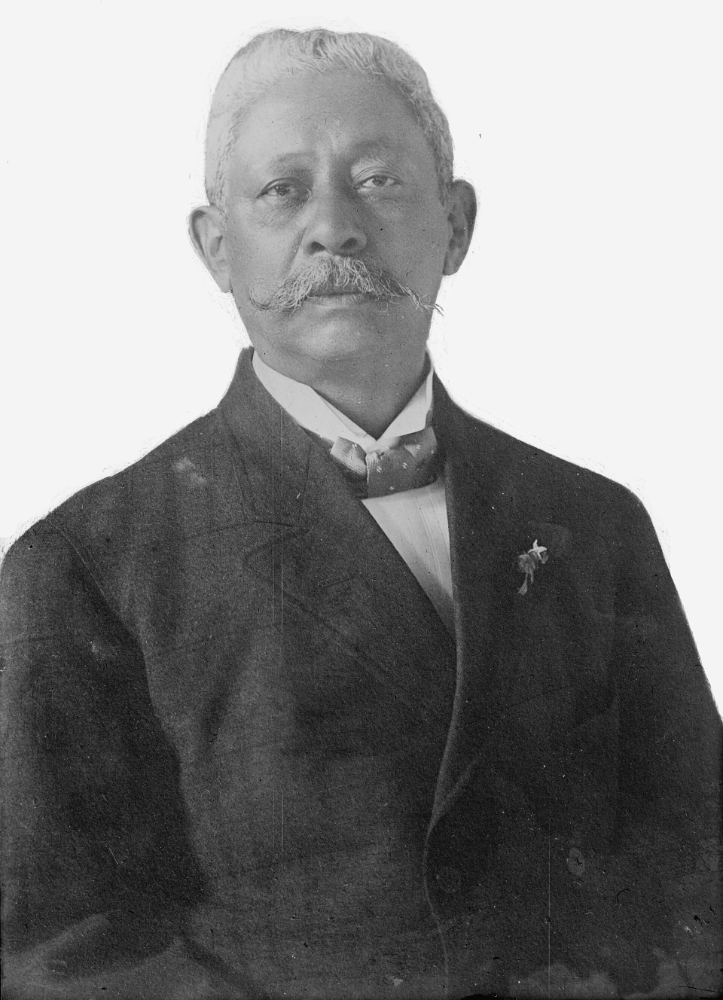

Harris & Ewing, [*Manuel Bonilla*](https://commons.wikimedia.org/wiki/File:Manuel_Bonilla.jpg), 1911 · Library of Congress via Wikimedia Commons, public domain.

He bought the Hornet, a former U.S. Navy ship, through a front man and sent Bonilla and a mercenary army to Honduras.

After La Ceiba fell, Honduras’s congress rejected the Morgan treaty 32 to 4, and Knox accepted Bonilla.

Washington wanted the debt settled and did not mind who ran Honduras.

## The new government wrote the terms he wanted

25 years

of concessions was what Bonilla’s congress granted Zemurray in 1912

He could import anything duty-free and build any railroad, and he got a $500,000 loan and 24,700 more acres.

In time Hondurans looked to him for water, health, and security, which a state normally supplies.

## Moving the government

Zemurray could not move his plantations, so he replaced the government. Why could a banana company do that in Honduras in 1911 when Apple could not do it in China in 2016?

What did Zemurray have that Apple lacked, and what did Honduras lack that China had?

# Why did the winner sell?

## Cuyamel was the better and the smaller business

Zemurray lived on his plantations and changed how bananas were grown, and United Fruit’s best men quit to join him.

In 1925 he turned down United Fruit’s offer to buy him out.

[figure not shown]

Cohen, *The Fish That Ate the Whale* (2012), ch. 11; percentages computed from Cohen’s figures.

A rival too small to fight head on and unwilling to sell had to be squeezed another way.

## United Fruit squeezed him through the state

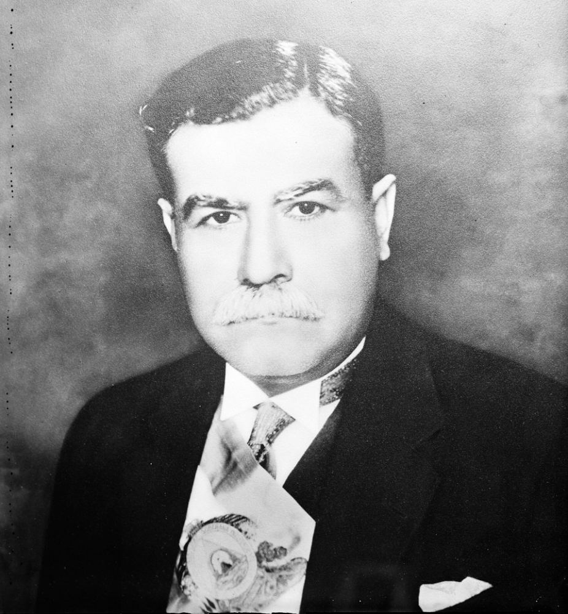

Harris & Ewing, [*Pres. Andino of Honduras*](https://commons.wikimedia.org/wiki/File:Pres._Andino_of_Honduras_LCCN2016878325.jpg), 1936 · Library of Congress via Wikimedia Commons, public domain.

Tiburcio Carías, close to United Fruit, refused Zemurray a permit to bridge the river his bananas had to cross.

United Fruit bought the headwaters of the rivers that watered his plantations.

Every asset he could not move gave anyone with a permit, a river, or a president a way to squeeze him.

# “Success limited his options and made him vulnerable.”

## Zemurray sold while he still could set the price

$30 million

was the value of the United Fruit stock Zemurray received for Cuyamel in 1929

The deal was a merger, so none of his workers were to be fired and no plantation closed.

In return he agreed to retire from the banana trade.

## Weakness or wealth

Was it the plantations he could not move, or the fortune he could lose, that made Zemurray sell in 1929?

What would he have risked by fighting on for another ten years?

# When does sunk investment weaken a firm?

## Expropriations peaked in the 1970s

[figure not shown]

Chris Hajzler, [*Expropriation of Foreign Direct Investments: Sectoral Patterns from 1993 to 2006*](https://ideas.repec.org/p/otg/wpaper/1011.html), 2010, Table 2, drawing on Kobrin (1984) and Minor (1994).

In the 1970s many governments, several of them newly independent, took over oil fields, mines, and plantations that foreign firms had built long before.

In an *obsolescing bargain*, a host government gains bargaining power once a foreign firm’s investment is sunk, and can then change the terms.

## Governments take what cannot leave

Oil, mines, plantations, and utilities made up nearly half of all expropriations from 1960 to 2006.

Each is tied to one place and useful for little else.

[figure not shown]

Hajzler (2010), Table 2; shares rebuilt from the table’s decade percentages.

An investment is *sunk* when it would be worth much less in any other place or use.